# Assignment V: GitHub and the ticketmaster.com API

Christopher Forschner (Student ID:6290771)

2023-01-30

I worked together with Janik Müller and Simon Andres in R and Python.

## Setting up a new GitHub repository

1. Register on github.com in case you have not done this already.
2. Initialize a new public repository for this assignment on GitHub.
3. For the following exercises of this assignment, follow the standard Git workflow (i.e., pull the latest version of the project to your local computer, then stage, commit, and push all the modifications that you make throughout the project). Every logical programming step should be well documented on GitHub with a meaningful commit message, so that other people (e.g., your course instructor) can follow and understand the development history. You can do this either using Shell commands or a Git GUI of your choice.
4. In the HTML file that you submit, include the hyperlink to the project repository (e.g., https://github. com/yourUserName/yourProjectName)

```r
git_url <- 'https://github.com/chrisfor97/Assignment05cf'
```

## Getting to know the API

5. Visit the documentation website for the API provided by ticketmaster.com (see here). Familiarize yourself with the features and functionalities of the Ticketmaster Discovery API. Have a particular look at rate limits. Features of the Ticketmaster Discovery API:
- Searching events by keyword in a certain location (lat/long)
- Getting events for a particular artist OR venue in a specific country/city/zip code/DMA/etc
- Getting hi-res images for a particular event or artist.
- Search events of a certain genre in a particular location for a certain promoter
- rate limits: 5000 API calls per day and rate limitation of 5 requests per second
  - increasing rate limit is also possible but specific conditions need to be fullfilled. However, for this Assignment, this is not necessary
6. Whithin the scope of this assignment, you do not have to request your own API key. Instead retrieve a valid key from the API Explorer. This API key enables you to perform the GET requests needed throughout this assignment. Even though this API key is not secret per se (it is publicly visible on the API Explorer website), please comply to the common secrecy practices discussed in the lecture and the tutorial: Treat the API key as a secret token. Your API key should neither appear in the code that you are submitting nor in your public GitHub repository.

#Interacting with the API - the basics (7) Perform a first GET request, that searches for event venues in Germany (countryCode = “DE”). Extract the content from the response object and inspect the resulting list. Describe what you can see.

```r
#get first info about the API
tickets_de <- GET('https://app.ticketmaster.com/discovery/v2/venues',
                  query=list("apikey"=ticketmaster_key,
                             "countryCode"="DE",
                             "locale"="*",
                             'size'=499)) %>% content

total_pages<-as.numeric(tickets_de$page$totalPages) #no of total pages
pagesize<-as.numeric(tickets_de$page$size) #page size
elements<-as.numeric(tickets_de$page$totalElements) #number of elements
```

```r
#define a function for requesting data
requester <-function(pages){
  #enforce a rate limit
  Sys.sleep(0.2)
  #call the api an get the respective page
  requ_page <- tickets_de <- GET('https://app.ticketmaster.com/discovery/v2/venues',
                  query=list("apikey"=ticketmaster_key,
                             "countryCode"="DE",
                             "locale"="*",
                             'page'=pages,
                             'size'=499)) %>% content #increasing to 499 per page so every element can be caught
  #return the search items in a list
  requ_page <-requ_page$`_embedded`$venues
}
```

different to python I changed the page size from the beginning. However, instead of a nested dictionary we have a nested list here in R. The number of elements stays the same.

8. Extract the name, the *city*, the *postalCode* and *address*, as well as the *url* and the *longitude* and *latitude* of the venues to a data frame. This data frame should have the following structure:

```r
tickets_de2 <-requester(0)
#exctract variable names
tickets_df1<-map(tickets_de2,~.x)
varnames=colnames(tickets_df1)
```

```r
tickets_df1 <- map(tickets_de2, as.data.frame) %>% #map them in a list
  map(~ complete(tibble(.x),)) %>% #replaces missing columns with a NA
  bind_rows() %>%
  select(c('name','name.1','line1','location.longitude','location.latitude','url','postalCode'))%>%
  rename(city = name.1, #rename columns in a proper name
         address = line1,
         latitude = location.latitude,
         longitude = location.longitude)
```

```r
#show the first 20 entries
tickets_df2<-head(tickets_df1,20)
tickets_df2
```

```
## # A tibble: 20 x 7
##    name                       city         address longi~1 latit~2 url   posta~3
##    <chr>                      <chr>        <chr>   <chr>   <chr>   <chr> <chr>
##  1 Grosse Freiheit 36         Hamburg      Grosse~ 9.9579~ 53.551~ http~ 22767
##  2 Gruenspan                  Hamburg      Grosse~ 9.9580~ 53.551~ http~ 22767
##  3 Huxleys Neue Welt          Berlin       Hasenh~ 13.421~ 52.486~ http~ 10967
##  4 Zentrum am Park            Emmelshausen Rhein-~ 7.55656 50.155~ http~ 56281
##  5 Stadthalle (Theatersaal)   Mülheim      Theodo~ 6.87471 51.427~ http~ 45479
##  6 Schlossgarten              Bruchsal     Schlos~ 8.59908 49.126~ http~ 76646
##  7 Stadthalle                 Hockenheim   Rathau~ 8.54908 49.318~ http~ 68766
##  8 FZW                        Dortmund     Ritter~ 7.4501  51.514~ http~ 44263
##  9 Arena Trier                Trier        Fort-W~ 6.66426 49.771~ http~ 54292
## 10 Eissporthalle              Memmingen    Hühner~ 10.162~ 47.979~ http~ 87700
## 11 Stadthalle Gersthofen      Gersthofen   Rathau~ 10.878~ 48.424~ http~ 86368
## 12 Feierwerk (Kranhalle)      Munich       Hansas~ 11.533~ 48.129~ http~ 81373
## 13 Feierwerk (Hansa 39)       Munich       Hansas~ 11.533~ 48.129~ http~ 81373
## 14 Burghof - STIMMEN-Festival Lörrach      Herren~ 7.65919 47.611~ http~ 79539
## 15 Schiesssportanlage         Neu Wulmsto~ Wesenb~ 9.79941 53.450~ http~ 21629
## 16 WUNDERINO ARENA            Kiel         Europa~ 10.131~ 54.320~ http~ 24103
## 17 Stadtpark Open Air         Hamburg      Saarla~ 10.0295 53.600~ http~ 22303
## 18 Laeiszhalle (Großer Saal)  Hamburg      Johann~ 9.98061 53.555~ http~ 20355
## 19 Friedrich-Ebert-Halle      Hamburg      Alter ~ 9.96507 53.464~ http~ 21075
## 20 myticket Jahrhunderthalle  Frankfurt a~ Pfaffe~ 8.51972 50.099~ http~ 65929
## # ... with abbreviated variable names 1: longitude, 2: latitude, 3: postalCode
```

## Interacting with the API - advanced

9. Have a closer look at the list element named page. Did your GET request from exercise (7) return all event locations in Germany? Obviously not - there are of course much more venues in Germany than those contained in this list. Your GET request only yielded the first results page containing the first 20 out of several thousands of venues. Check the API documentation under the section Venue Search. How can you request the venues from the remaining results pages? Iterate over the results pages and perform GET requests for all venues in Germany. After each iteration, extract the seven variables name, city, postalCode, address, url, longitude, and latitude. Join the information in one large data frame. Print the first 10 rows and the shape of the resulting data frame. The resulting data frame should look something like this (note that the exact number of search results may have changed since this document has been last modified):

```r
#get all pages for venues in Germany
venueslist_de<-map(0:total_pages,requester)

venueslist_de2<-venueslist_de[-which(sapply(venueslist_de, is.null))] #removing all list entries where list type is null
de_length<-as.numeric(length(venueslist_de2))
#dropped the 26th page, because it caused Problems I could not find a solution for


venues_de_df<-data.frame() #create empty data frame
for (p in 1:de_length){
  elements<-as.numeric(length(venueslist_de2[[p]])) #create empty lists for every column in the data frame
  names<-vector("list",elements)
  city<-vector("list",elements)
  postal_Code<-vector("list",elements)
  url <-vector("list",elements)
  latitude<-vector("list",elements)
  longitude<-vector("list",elements)
  address<-vector("list",elements)

  for(e in 1:elements){ #check if element of  the list, otherwise NA
    if (venueslist_de2[[p]][[e]]$name %in% venueslist_de2[[p]][[e]]){
      names[e]<-venueslist_de2[[p]][[e]]$name}
    else{names[e]<-NA}

    if (!is.null(venueslist_de2[[p]][[e]]$postalCode)){
    postal_Code[e]<-venueslist_de2[[p]][[e]]$postalCode}
    else{postal_Code[e]<-NA}

    if (!is.null(venueslist_de2[[p]][[e]]$url)){
    url[e]<-venueslist_de2[[p]][[e]]$url}
    else{url[e]<-NA}

    if (!is.null(venueslist_de2[[p]][[e]]$location)){
    longitude[e]<-venueslist_de2[[p]][[e]]$location$longitude
    latitude[e]<-venueslist_de2[[p]][[e]]$location$latitude}
    else{longitude[e]<-NA
      latitude[e]<-NA}

    if (!is.null(venueslist_de2[[p]][[e]]$city)){
    city[e]<-venueslist_de2[[p]][[e]]$city$name}
    else{city[e]<-NA}

    if (!is.null(venueslist_de2[[p]][[e]]$address)){
    if (!is.null(venueslist_de2[[p]][[e]]$address$line1)){
      address[e]<-venueslist_de2[[p]][[e]]$address$line1}
    else{address[e]<-NA}}
    else{address[e]<-NA}

  }
  venues_de_df2<-data.frame(unlist(names), #create data frame of the produced lists
                            unlist(postal_Code),
                            unlist(city),
                            unlist(longitude),
                            unlist(latitude),
                            unlist(url),
                            unlist(address))
  venues_de_df<-rbind(venues_de_df,venues_de_df2)
}
venues_de_df<-venues_de_df %>%rename(name=unlist.names., #renaming
         city=unlist.city.,
         postalCode=unlist.postal_Code.,
         adress=unlist.address.,
         longitude=unlist.longitude.,
         latitude=unlist.latitude.,
         url=unlist.url.)

venues_de_df$latitude<-venues_de_df$latitude  %>% as.numeric() #transform latitude and longitude
venues_de_df$longitude<-venues_de_df$longitude  %>% as.numeric()#in numerics
head(venues_de_df,10)
```

```
##                        name postalCode         city longitude latitude
## 1        Grosse Freiheit 36      22767      Hamburg  9.957905 53.55119
## 2                 Gruenspan      22767      Hamburg  9.958075 53.55188
## 3         Huxleys Neue Welt      10967       Berlin 13.421380 52.48639
## 4           Zentrum am Park      56281 Emmelshausen  7.556560 50.15544
## 5  Stadthalle (Theatersaal)      45479      Mülheim  6.874710 51.42778
## 6             Schlossgarten      76646     Bruchsal  8.599080 49.12692
## 7                Stadthalle      68766   Hockenheim  8.549080 49.31849
## 8                       FZW      44263     Dortmund  7.450100 51.51481
## 9               Arena Trier      54292        Trier  6.664260 49.77183
## 10            Eissporthalle      87700    Memmingen 10.162930 47.97999
##                                                                                         url
## 1                                                   http://www.ticketmaster.de/venue/287636
## 2                                                   http://www.ticketmaster.de/venue/287155
## 3                                                   http://www.ticketmaster.de/venue/286842
```

[output cut: 18 more lines]

# Visualizing the extracted data

10. Below, you can find code that produces a map of Germany. Add points to the map indicating the locations of the event venues across Germany.

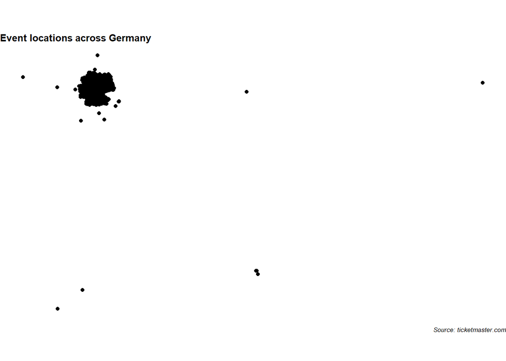

```r
ggplot(data = venues_de_df) +
  borders("world", "Germany", colour = "black", fill = "grey90") +
  theme_void() +
  coord_quickmap() +
  geom_point(mapping = aes(x=longitude,y=latitude))+#adding a scatterplot to the Map
  labs(title = "Event locations across Germany",
       caption = "Source: ticketmaster.com") +
  theme(title = element_text(size=8, face='bold'),
        plot.caption = element_text(face = "italic"))
```

11. You will find that some coordinates lie way beyond the German borders and can be assumed to be faulty. Set coordinate values to NA where the value of longitude is outside the range (5.866, 15.042) or where the value of latitude is outside the range (47.270, 55.059) (these coordinate ranges have been derived from the extreme points of Germany as listed on Wikipedia (see here). For extreme points of other countries, see here).

```r
venues_de_df2<-venues_de_df #replace values if they are outside the extrem points
venues_de_df2$longitude[venues_de_df2$longitude>15.042]<-NA
venues_de_df2$longitude[venues_de_df2$longitude<5.886]<-NA
venues_de_df2$latitude[venues_de_df2$latitude>55.059]<-NA
venues_de_df2$latitude[venues_de_df2$latitude<47.270]<-NA
head(venues_de_df2)
```

```
##                       name postalCode         city longitude latitude
## 1       Grosse Freiheit 36      22767      Hamburg  9.957905 53.55119
## 2                Gruenspan      22767      Hamburg  9.958075 53.55188
## 3        Huxleys Neue Welt      10967       Berlin 13.421380 52.48639
## 4          Zentrum am Park      56281 Emmelshausen  7.556560 50.15544
## 5 Stadthalle (Theatersaal)      45479      Mülheim  6.874710 51.42778
## 6            Schlossgarten      76646     Bruchsal  8.599080 49.12692
##                                                                                        url
## 1                                                  http://www.ticketmaster.de/venue/287636
## 2                                                  http://www.ticketmaster.de/venue/287155
## 3                                                  http://www.ticketmaster.de/venue/286842
## 4    https://www.ticketmaster.de/venue/zentrum-am-park-emmelshausen-tickets/elszentrum/701
## 5 https://www.ticketmaster.de/venue/stadthalle-theatersaal--mulheim-tickets/mrustadtth/711
## 6          https://www.ticketmaster.de/venue/schlossgarten-bruchsal-tickets/bruparkanl/701
##                  adress
## 1    Grosse Freiheit 36
## 2    Grosse Freiheit 58
## 3  Hasenheide 107 – 113
## 4 Rhein-Mosel-Straße 45
## 5 Theodor-Heuss-Platz 1
## 6      Schloss Bruchsal
```

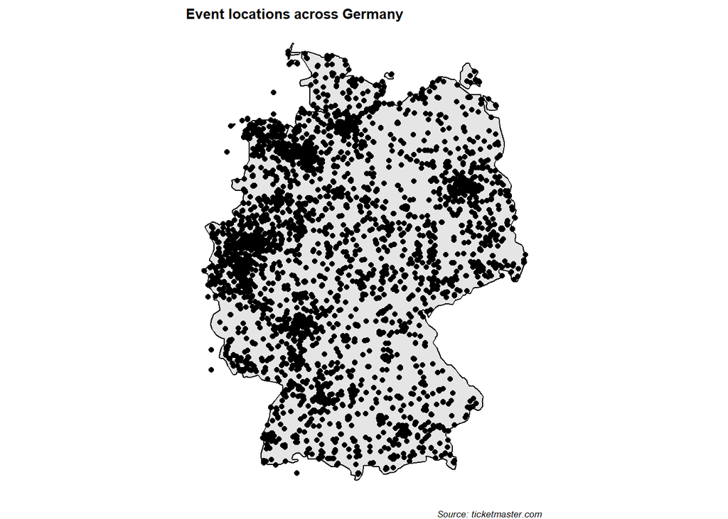

```r
ggplot(data = venues_de_df2) + #new data base
  borders("world", "Germany", colour = "black", fill = "grey90") +
  theme_void() +
  coord_quickmap() +
  geom_point(mapping = aes(x=longitude,y=latitude))+
  labs(title = "Event locations across Germany",
       caption = "Source: ticketmaster.com") +
  theme(title = element_text(size=8, face='bold'),
        plot.caption = element_text(face = "italic"))
```

## Event locations in other countries (12) Repeat exercises (9)–(11) for another European country of your choice. (Hint: Clean code pays off! If you have coded the exercises efficiently, only very few adaptions need to be made.)

My country of Choice: Switzerland

```r
#adjust the requester function
requester2 <-function(pages){
  #enforce a rate limit
  Sys.sleep(0.2)
  #call the api an get the respective page
  requ_page <- tickets_de <- GET('https://app.ticketmaster.com/discovery/v2/venues',
                  query=list("apikey"=ticketmaster_key,
                             "countryCode"="CH",
                             "locale"="*",
                             'page'=pages,
                             "size"=499)) %>% content #increasing to 499 per page so every element can be caught
  #return the search items in a list
  requ_page <-requ_page$`_embedded`$venues
}
```

```r
#getting an overview over the data
tickets_ch <- GET('https://app.ticketmaster.com/discovery/v2/venues',
                  query=list("apikey"=ticketmaster_key,
                             "countryCode"="CH",
                             "locale"="*",
                             'size'=499)) %>% content

total_pages_ch<-as.numeric(tickets_ch$page$totalPages)
elements_ch<-as.numeric(tickets_ch$page$totalElements)
```

```r
#get all pages for venues in Germany
venueslist_ch<-map(0:total_pages_ch,requester2)

venueslist_ch2<-venueslist_ch[-which(sapply(venueslist_ch, is.null))] #removing all list entries where list type is null
ch_length<-as.numeric(length(venueslist_ch2))
#dropped the 26th page, because it caused Problems I could not find a solution for
#venueslist_de3<-venueslist_de2[-26]
venuesch_df<-data.frame()
length_ch<-length(venueslist_ch2[[1]])
venueslist_ch3<-venueslist_ch2[[1]]
```

```r
#same procedure as in exercise 9
names<-vector("list",elements_ch)
city<-vector("list",elements_ch)
postal_Code<-vector("list",elements_ch)
url <-vector("list",elements_ch)
latitude<-vector("list",elements_ch)
longitude<-vector("list",elements_ch)
address<-vector("list",elements_ch)

for (i in 1:elements_ch){
if (venueslist_ch3[[i]]$name %in% venueslist_ch3[[i]]){
  names[i]<-venueslist_ch3[[i]]$name
} else{
  names[i]<-NA
}}

for (i in 1:elements_ch) {
  if (!is.null(venueslist_ch3[[i]]$postalCode)){
    postal_Code[i]<-venueslist_ch3[[i]]$postalCode}
  else{postal_Code[i]<-NA}}

for (i in 1:elements_ch) {
  if (!is.null(venueslist_ch3[[i]]$url)){
    url[i]<-venueslist_ch3[[i]]$url}
  else{
    url[i]<-NA}}

for (i in 1:elements_ch) {
  if (!is.null(venueslist_ch3[[i]]$location)){
    longitude[i]<-venueslist_ch3[[i]]$location$longitude
    latitude[i]<-venueslist_ch3[[i]]$location$latitude}
  else{
    longitude[i]<-NA
    latitude[i]<-NA}}

for (i in 1:elements_ch) {
  if (!is.null(venueslist_ch3[[i]]$city)){
    city[i]<-venueslist_ch3[[i]]$city$name}
  else{
    city[i]<-NA
  }
}

for (i in 1:elements_ch) {
  if (!is.null(venueslist_ch3[[i]]$city)){
    city[i]<-venueslist_ch3[[i]]$city$name}
  else{
    city[i]<-NA
  }
}
for (i in 1:elements_ch) {
  if (!is.null(venueslist_ch3[[i]]$address)){
    if (!is.null(venueslist_ch3[[i]]$address$line1)){
      address[i]<-venueslist_ch3[[i]]$address$line1}
    else{address[i]<-NA}
    }

  else{
    address[i]<-NA
  }
}
venues_ch_df<-data.frame(unlist(names),
                         unlist(city),
                         unlist(postal_Code),
                         unlist(address),
                         unlist(longitude),
                         unlist(latitude),
                         unlist(url))
venues_ch_df<-venues_ch_df %>%rename(name=unlist.names.,
         city=unlist.city.,
         postalCode=unlist.postal_Code.,
         adress=unlist.address.,
         longitude=unlist.longitude.,
         latitude=unlist.latitude.,
         url=unlist.url.)
venues_ch_df$longitude<-as.numeric(venues_ch_df$longitude)
venues_ch_df$latitude<-as.numeric(venues_ch_df$latitude)
head(venues_ch_df)
```

```
##                     name                city postalCode                  adress
## 1    Salle de l'Alhambra              Genève       1204 Rue de la Rôtisserie 10
## 2 Kulturfabrik KUFA Lyss                Lyss       3250         Werdtstrasse 17
## 3      Klostersaal Stans               Stans       6370          Mürgstrasse 18
## 4     ILFISHALLE Langnau Langnau im Emmental       3550         Güterstrasse 14
## 5     Stadion Letzigrund              Zürich       8048      Badenerstrasse 500
## 6         St Jakobshalle               Basel       4052  St. Jakobs-Strasse 390
##   longitude latitude
## 1   6.14652 46.20272
## 2   7.29471 47.08075
## 3   8.36912 46.95569
## 4   7.78612 46.93628
## 5   8.50377 47.38265
## 6   7.61821 47.54040
##                                                                                               url
## 1                https://www.ticketmaster.ch/venue/salle-de-lalhambra-geneve-tickets/alhambra/103
## 2              https://www.ticketmaster.ch/venue/kulturfabrik-kufa-lyss-lyss-tickets/kufalyss/103
## 3                https://www.ticketmaster.ch/venue/klostersaal-stans-stans-tickets/stankloste/103
## 4 https://www.ticketmaster.ch/venue/ilfishalle-langnau-langnau-im-emmental-tickets/ilfishalle/114
## 5              https://www.ticketmaster.ch/venue/stadion-letzigrund-zurich-tickets/letzigrund/108
## 6                   https://www.ticketmaster.ch/venue/st-jakobshalle-basel-tickets/stjakobbas/103
```

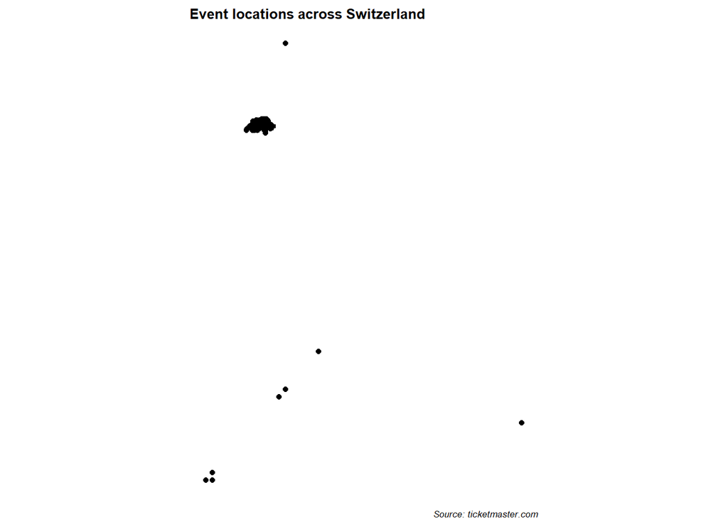

```r
#same procedure as in exercise 10
ggplot(data = venues_ch_df) +
  borders("world", "Switzerland", colour = "black", fill = "grey90") +
  theme_void() +
  coord_quickmap() +
  geom_point(mapping = aes(x=longitude,y=latitude))+
  labs(title = "Event locations across Switzerland",
       caption = "Source: ticketmaster.com") +
  theme(title = element_text(size=8, face='bold'),
        plot.caption = element_text(face = "italic"))
```

```r
#same procedure as in exercise 11
venues_ch_df2<-venues_ch_df
venues_ch_df2$longitude[venues_ch_df2$longitude>10.29]<-NA
venues_ch_df2$longitude[venues_ch_df2$longitude<5.57]<-NA
venues_ch_df2$latitude[venues_ch_df2$latitude>47.48]<-NA
venues_ch_df2$latitude[venues_ch_df2$latitude<45.49]<-NA
head(venues_ch_df2)
```

```
##                     name                city postalCode                  adress
## 1    Salle de l'Alhambra              Genève       1204 Rue de la Rôtisserie 10
## 2 Kulturfabrik KUFA Lyss                Lyss       3250         Werdtstrasse 17
## 3      Klostersaal Stans               Stans       6370          Mürgstrasse 18
## 4     ILFISHALLE Langnau Langnau im Emmental       3550         Güterstrasse 14
## 5     Stadion Letzigrund              Zürich       8048      Badenerstrasse 500
## 6         St Jakobshalle               Basel       4052  St. Jakobs-Strasse 390
##   longitude latitude
## 1   6.14652 46.20272
## 2   7.29471 47.08075
## 3   8.36912 46.95569
## 4   7.78612 46.93628
## 5   8.50377 47.38265
## 6   7.61821       NA
##                                                                                               url
## 1                https://www.ticketmaster.ch/venue/salle-de-lalhambra-geneve-tickets/alhambra/103
## 2              https://www.ticketmaster.ch/venue/kulturfabrik-kufa-lyss-lyss-tickets/kufalyss/103
## 3                https://www.ticketmaster.ch/venue/klostersaal-stans-stans-tickets/stankloste/103
## 4 https://www.ticketmaster.ch/venue/ilfishalle-langnau-langnau-im-emmental-tickets/ilfishalle/114
## 5              https://www.ticketmaster.ch/venue/stadion-letzigrund-zurich-tickets/letzigrund/108
## 6                   https://www.ticketmaster.ch/venue/st-jakobshalle-basel-tickets/stjakobbas/103
```

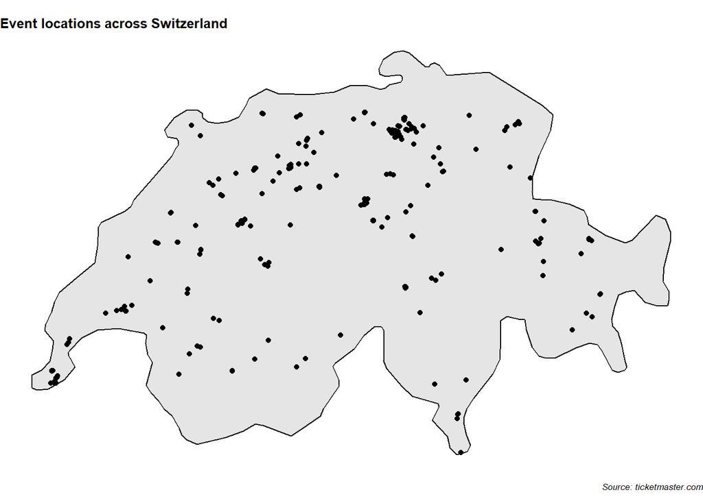

```r
ggplot(data = venues_ch_df2) + #new database
  borders("world", "Switzerland", colour = "black", fill = "grey90") +
  theme_void() +
  coord_quickmap() +
  geom_point(mapping = aes(x=longitude,y=latitude))+
  labs(title = "Event locations across Switzerland",
       caption = "Source: ticketmaster.com") +
  theme(title = element_text(size=8, face='bold'),
        plot.caption = element_text(face = "italic"))
```